# Public Health and Economic Consequences of Storms

## Data Processing

Download file, format date time

```r
url1 <- "https://d396qusza40orc.cloudfront.net/repdata%2Fdata%2FStormData.csv.bz2"
if(!file.exists("stormdata.csv.bz2")){download.file(url1, "stormdata.csv.bz2")}
stormdata <- read.csv("stormdata.csv.bz2")
url2 <- "https://d396qusza40orc.cloudfront.net/repdata%2Fpeer2_doc%2Fpd01016005curr.pdf"
if(!file.exists("info.pdf")){download.file(url2,"info.pdf")}
```

```r
stormdata$BGN_DATE <- strptime(stormdata$BGN_DATE, "%m/%d/%Y %H:%M:%S")
year <- stormdata$BGN_DATE
year <- year$year
stormdata$year <- year + 1900
```

Processing

```r
library(dplyr)
```

```r
dmgdata <- select(stormdata, year, STATE, EVTYPE, INJURIES, FATALITIES,
                   PROPDMG, CROPDMG)
tstmwind <- unique(grep("TSTM", dmgdata$EVTYPE, value = TRUE))
tstmwind <- tstmwind[tstmwind != 'NON-TSTM WIND' & tstmwind != 'NON TSTM WIND'
                     & tstmwind != "TORNADOES, TSTM WIND, HAIL"]
dmgdata$EVTYPE[dmgdata$EVTYPE %in% tstmwind] <- 'THUNDERSTORM WIND'
dmgdata$EVTYPE[dmgdata$EVTYPE == 'HEAT'] <- 'EXCESSIVE HEAT'
```

In order to determine the most damageing storm types in regard to public health and property damage, data for injuries, fatalities, property and crop damage were selected. Data was analyzed looking at the whole year to limit effects of seasonal change and determine overall impact so only the year of the event was kept for analysis. This analysis focuses on the impact across the US, however state designation was kept in the rearranged dataset as it may be useful in further analysis for more focused policy decisions. Several factor levels that distinguished between different strengths of thunderstorm wind were combined as the study aimed to rank general storm types.

```r
ymedian <- median(dmgdata$year)
dmgdata <- filter(dmgdata, year >= ymedian)
```

The full dataset includes entries from the years 1950 - 2011. However, the median year is 2002. This indicates that half of the data falls within the last decade of six. The analysis focuses on the data collected from the median year and later to limit the effect of increased record collection over time.

## Results

### Ranking Storms by Damage Parameters

```r
library(reshape2)
dmgmelt <- melt(dmgdata, id.vars = c("year","STATE", "EVTYPE"))
dmgsum <- dcast(dmgmelt, year + EVTYPE ~ variable, sum)
```

First yearly sums were calculated for each storm type.

```r
meandmg <- summarise(group_by(dmgsum, EVTYPE), injury = mean(INJURIES),
                   fatality = mean(FATALITIES), prop = mean(PROPDMG),
                   crop = mean(CROPDMG))
topinj <- arrange(meandmg, desc(injury))[1:5,1]
topftl <- arrange(meandmg, desc(fatality))[1:5,1]
topprop <- arrange(meandmg, desc(prop))[1:5,1]
topcrop <- arrange(meandmg, desc(crop))[1:5,1]
```

In order to determine the most damaging storm types, the yearly sums were averaged across the data for each parameter. The storm types with the highest mean for each value were stored.

*Highest Injuries*

```r
c(sapply(topinj, as.character))
```

```
## [1] "TORNADO"           "EXCESSIVE HEAT"    "HURRICANE/TYPHOON"
## [4] "THUNDERSTORM WIND" "LIGHTNING"
```

*Highest Fatalities*

```r
c(sapply(topftl, as.character))
```

```
## [1] "TORNADO"        "EXCESSIVE HEAT" "FLASH FLOOD"    "LIGHTNING"
## [5] "RIP CURRENT"
```

*Highest Property Damage*

```r
c(sapply(topprop, as.character))
```

```
## [1] "THUNDERSTORM WIND" "FLASH FLOOD"       "TORNADO"
## [4] "FLOOD"             "HAIL"
```

*Highest Crop Damage*

```r
c(sapply(topcrop, as.character))
```

```
## [1] "HAIL"              "FLASH FLOOD"       "FLOOD"
## [4] "THUNDERSTORM WIND" "TORNADO"
```

### Yearly Public Health Consequences

```r
inj <- filter(dmgsum, EVTYPE %in% c(sapply(topinj, as.character)))
fat <- filter(dmgsum, EVTYPE %in% c(sapply(topftl, as.character)))
```

Each yearly sum for injuries and fatalities was plotted to give greater detail as to how the storm rankings changed over the time period of analysis.

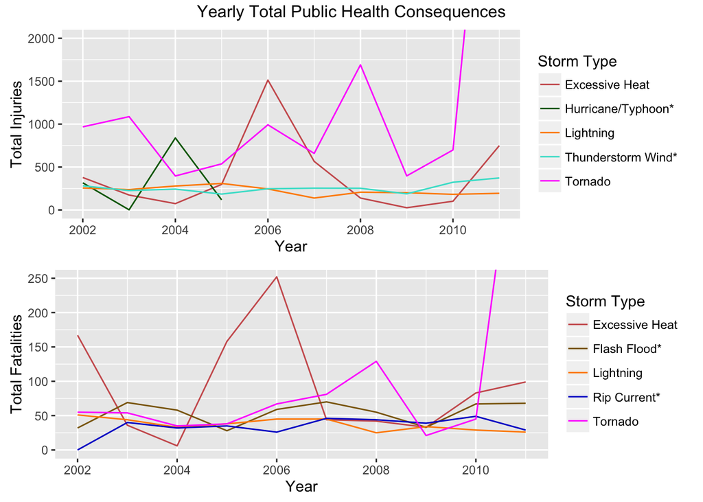

```r
library(ggplot2)
library(gridExtra)
Injuries <- ggplot(inj, aes(x= year, y = INJURIES, col = EVTYPE)) +
        geom_line() +
        coord_cartesian(ylim = c(0,2000))+
        ylab("Total Injuries") +
        xlab("Year") +
        scale_color_manual(values = c("indianred", "darkgreen", "darkorange",
                "turquoise", "magenta"), name = "Storm Type", labels =
                c("Excessive Heat", "Hurricane/Typhoon*", "Lightning",
                "Thunderstorm Wind*", "Tornado"))

Fatalities <- ggplot(fat, aes(x= year, y = FATALITIES, col = EVTYPE)) +
        geom_line() +
        coord_cartesian(ylim = c(0,250))+
        ylab("Total Fatalities") +
        xlab("Year") +
        scale_color_manual(values = c("indianred", "darkgoldenrod4", "darkorange",
                "blue3", "magenta"), name = "Storm Type", labels =
                c("Excessive Heat", "Flash Flood*", "Lightning", "Rip Current*",
                  "Tornado"))


grid.arrange(Injuries, Fatalities, ncol = 1,
             top = "Yearly Total Public Health Consequences")
```

Storms marked wth an * are different between the injury and fatality rankings. Beyond the storm types with the highest injury and fatality rates, the plot shows that excessive heat and tornados appear to have greater swings in the year to year impact on public health. Tornado injury and fatality data for 2011 was cut off from the plot as an outlier to show greater detail, however the slope of the line was maintained.

### Yearly Economic Consequences

```r
prop <- filter(dmgsum, EVTYPE %in% c(sapply(topprop, as.character)))
crop <- filter(dmgsum, EVTYPE %in% c(sapply(topcrop, as.character)))
```

Each yearly sum for crop and property damage was plotted to give greater detail as to how the storm rankings changed over the time period of analysis.

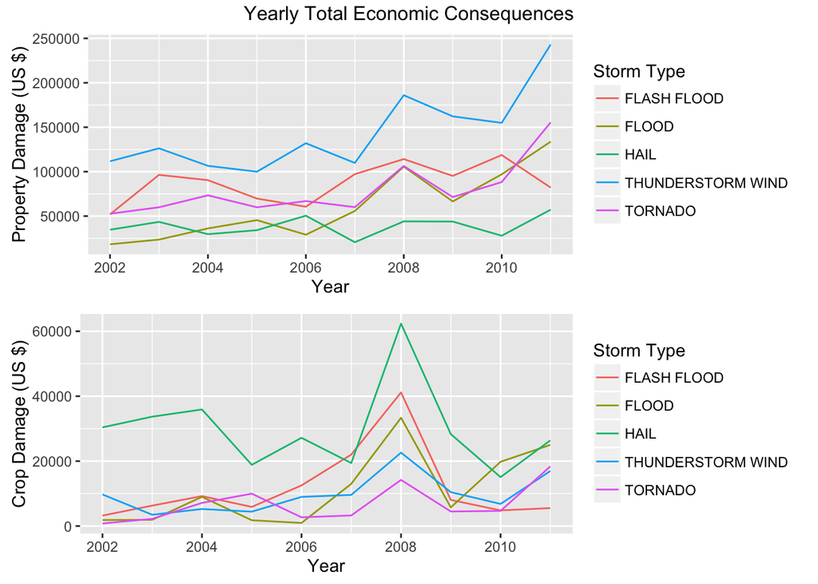

```r
library(ggplot2)
library(gridExtra)
Property <- ggplot(prop, aes(x= year, y = PROPDMG, col = EVTYPE)) +
        geom_line() +
        ylab("Property Damage (US $)") +
        xlab("Year") +
        guides(color=guide_legend(title="Storm Type"))

Cropplot <- ggplot(crop, aes(x= year, y = CROPDMG, col = EVTYPE)) +
        geom_line() +
        ylab("Crop Damage (US $)") +
        xlab("Year") +
        guides(color=guide_legend(title="Storm Type"))

grid.arrange(Property, Cropplot, ncol = 1,
             top = "Yearly Total Economic Consequences")
```